# Decision_Trees_&_Random_Forest

# Practical Work 5

```r
setwd("C:/Users/flavi/OneDrive/Documents/ESILV/A4/S1/Machine Learning/Machine_learning/PW4 - Decision Trees & Random Forests")
```

## Regression Trees

### Single Tree

#### 1) Load the Boston dataset from MASS package. Split the dataset randomly in half.

```r
library(MASS)
library(caTools)
set.seed(18)
Boston_idx = sample(1:nrow(Boston), nrow(Boston) / 2)
# You don't know what we just did?
# open the documentation of the function sample by
# writing ?sample in the R console.
# Note that this is one of the ways to split it randomly and it is not necessary the best.
Boston_train = Boston[Boston_idx,]
Boston_test  = Boston[-Boston_idx,]
```

#### 2) Fit a regression tree to the training data using the rpart() function from the rpart package. Name the tree Boston_tree.

```r
library(rpart)
Boston_tree = rpart(medv ~., data=Boston_train)
Boston_tree
```

```
n= 253

node), split, n, deviance, yval
      * denotes terminal node

 1) root 253 19858.11000 21.99802
   2) lstat>=5.27 219  7420.35000 19.49954
     4) lstat>=14.4 92  1798.17900 14.81522
       8) crim>=5.7819 44   648.06430 12.18864 *
       9) crim< 5.7819 48   568.30480 17.22292 *
     5) lstat< 14.4 127  2141.02400 22.89291
      10) rm< 6.611 104   991.45380 21.95769 *
      11) rm>=6.611 23   647.29910 27.12174
        22) tax>=268.5 16   268.14940 24.80625 *
        23) tax< 268.5 7    97.28857 32.41429 *
   3) lstat< 5.27 34  2265.02700 38.09118
     6) rm< 7.433 21   686.16950 32.90476 *
     7) rm>=7.433 13   101.48770 46.46923 *
```

#### 3) Plot the obtained tree using the following code.

```r
plot(Boston_tree)
text(Boston_tree, pretty = 0)
```

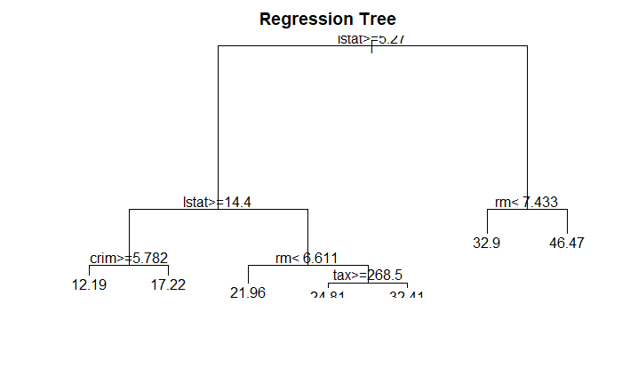

```r
title(main = "Regression Tree")
```

#### 4) A better plot can be obtained using the rpart.plot18 package. Re-plot the tree using it. You can use the rpart.plot() function which by default, when the output is continuous, each node shows: the predicted value, and the percentage of observations in the node. You can also use the prp() function.

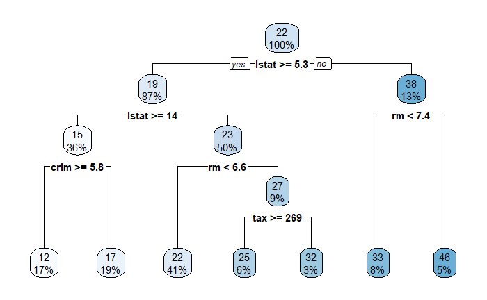

```r
library(rpart.plot)
rpart.plot(Boston_tree)
```

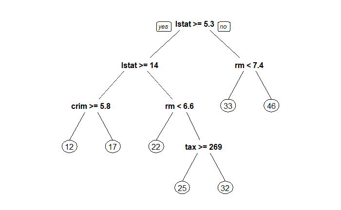

```r
prp(Boston_tree)
```

#### 5) Print the obtained tree and print its summary. Between the things that you can see in the summary, the CP (complexity parameter) table and the importance of each variable in the model. Print the CP table using the printcp() function to see the cross validation results. Plot a comparison figure using the plotcp() function.

```r
summary(Boston_tree)
```

```
Call:
rpart(formula = medv ~ ., data = Boston_train)
  n= 253

          CP nsplit rel error    xerror       xstd
1 0.51227092      0 1.0000000 1.0079237 0.12063261
2 0.17530106      1 0.4877291 0.6269968 0.08009188
3 0.07439632      2 0.3124280 0.4181044 0.06301976
4 0.02929834      3 0.2380317 0.3886623 0.06765051
5 0.02529297      4 0.2087334 0.3489906 0.06171012
6 0.01419376      5 0.1834404 0.3172825 0.05624605
7 0.01000000      6 0.1692466 0.3051705 0.05617950

Variable importance
lstat    rm   age   tax   dis indus   nox  crim   rad    zn black
   40    17     9     7     7     6     5     5     2     1     1

Node number 1: 253 observations,    complexity param=0.5122709
  mean=21.99802, MSE=78.49055
  left son=2 (219 obs) right son=3 (34 obs)
  Primary splits:
      lstat   < 5.27    to the right, improve=0.5122709, (0 missing)
      rm      < 6.978   to the left,  improve=0.4501026, (0 missing)
      indus   < 7.625   to the right, improve=0.3122330, (0 missing)
      ptratio < 19.65   to the right, improve=0.2830922, (0 missing)
      nox     < 0.5125  to the right, improve=0.2710296, (0 missing)
  Surrogate splits:
      rm    < 6.978   to the left,  agree=0.917, adj=0.382, (0 split)
      age   < 17.1    to the right, agree=0.881, adj=0.118, (0 split)
      crim  < 0.03402 to the right, agree=0.877, adj=0.088, (0 split)
      zn    < 87.5    to the left,  agree=0.870, adj=0.029, (0 split)
      indus < 1.605   to the right, agree=0.870, adj=0.029, (0 split)

Node number 2: 219 observations,    complexity param=0.1753011
  mean=19.49954, MSE=33.88288
  left son=4 (92 obs) right son=5 (127 obs)
  Primary splits:
      lstat   < 14.4    to the right, improve=0.4691352, (0 missing)
      crim    < 5.84803 to the right, improve=0.3530712, (0 missing)
      ptratio < 19.9    to the right, improve=0.3072113, (0 missing)
```

[output cut: 74 more lines]

```
      tax     < 268.5   to the right, improve=0.4354419, (0 missing)
      ptratio < 18.7    to the right, improve=0.3278305, (0 missing)
      indus   < 4.415   to the right, improve=0.2124938, (0 missing)
      rm      < 6.978   to the left,  improve=0.1449609, (0 missing)
      nox     < 0.5225  to the right, improve=0.1122918, (0 missing)
  Surrogate splits:
      indus   < 2.21    to the right, agree=0.783, adj=0.286, (0 split)
      rm      < 7.1455  to the left,  agree=0.783, adj=0.286, (0 split)
      ptratio < 13.9    to the right, agree=0.783, adj=0.286, (0 split)

Node number 22: 16 observations
  mean=24.80625, MSE=16.75934

Node number 23: 7 observations
  mean=32.41429, MSE=13.89837
```

```r
printcp(Boston_tree)
```

```
Regression tree:
rpart(formula = medv ~ ., data = Boston_train)

Variables actually used in tree construction:
[1] crim  lstat rm    tax

Root node error: 19858/253 = 78.491

n= 253

        CP nsplit rel error  xerror     xstd
1 0.512271      0   1.00000 1.00792 0.120633
2 0.175301      1   0.48773 0.62700 0.080092
3 0.074396      2   0.31243 0.41810 0.063020
4 0.029298      3   0.23803 0.38866 0.067651
5 0.025293      4   0.20873 0.34899 0.061710
6 0.014194      5   0.18344 0.31728 0.056246
7 0.010000      6   0.16925 0.30517 0.056180
```

#### 6) Write a function that returns the RMSE of two vectors.

```r
RMSE = function(y, y_hat) {
  sqrt(mean((y - y_hat) ^ 2))
}
```

#### 7) Use the function predict() to predict the response on the test set. Then calculate the RMSE obtained with tree model.

```r
Boston_tree_predictions = predict(Boston_tree, newdata = Boston_test)
RMSE(Boston_tree_predictions, Boston_test$medv)
```

```
[1] 5.051138
```

#### 8) Fit a linear regression model on the training set. Then predict the response on the test set using the linear model. Calculate the RMSE and compare the performance of the tree and the linear regression model.

```r
Boston_lm = lm(medv~., data = Boston_train)
Boston_lm_predictions = predict(Boston_lm, newdata = Boston_test)
RMSE(Boston_lm_predictions, Boston_test$medv)
```

```
[1] 5.016083
```

Let’s print the figures

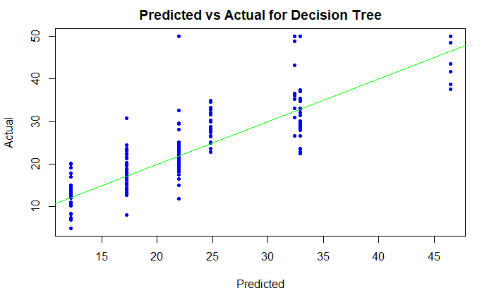

```r
plot(Boston_tree_predictions, Boston_test$medv,
     xlab = "Predicted", ylab = "Actual",
     main = "Predicted vs Actual for Decision Tree",
     col = "blue", pch = 20)
abline(0, 1, col = "green")
```

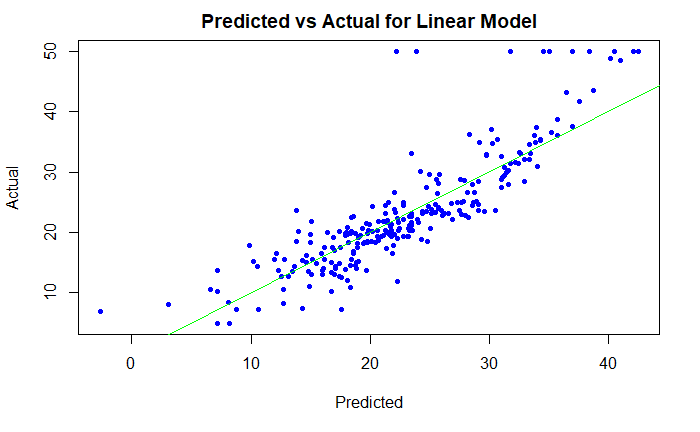

```r
plot(Boston_lm_pred, Boston_test$medv,
     xlab = "Predicted", ylab = "Actual",
     main = "Predicted vs Actual for Linear Model",
     col = "blue", pch = 20)
abline(0, 1, col = "green")
```

### Bagging

#### 9) Fit a bagged model, using the randomForest() function from the randomForest package.

```r
library(randomForest)
Boston_bagging = randomForest(medv ~ ., data = Boston_train, mtry = ncol(Boston_train)-1)
```

#### 10) Predict the response on the test set using the bagging model. Calculate the RMSE. Is the performance of the model better than linear regression or a simple tree?

```r
Boston_bagging_predictions = predict(Boston_bagging, newdata = Boston_test)
RMSE(Boston_bagging_predictions, Boston_test$medv)
```

```
[1] 3.909783
```

The RMSE if much lower with bagging than th linear regression and a simple tree.

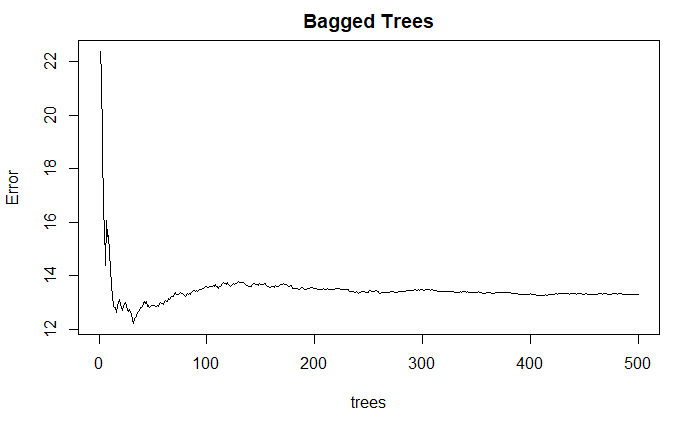

```r
plot(Boston_bagging, main = "Bagged Trees")
```

### Random Forests

#### 11) Fit a random forest on the training set and compare its performance with the previous models by calculating the predictions and the RMSE.

```r
Boston_random_forest = randomForest(medv ~ ., data = Boston_train, mtry = (ncol(Boston_train)-1)/3, importance = TRUE, ntrees = 500)
Boston_random_forest_predictions = predict(Boston_random_forest, newdata = Boston_test)
RMSE(Boston_random_forest_predictions, Boston_test$medv)
```

```
[1] 4.144996
```

#### 12) Use the function importance() from the randomForest package to see the most important predictors in the obtained random forest model. What are the three most important predictors? Did you find the same results when you selected the best predictors for the linear regression model during session 2?

```r
importance(Boston_random_forest)
```

```
          %IncMSE IncNodePurity
crim    14.359554    1385.48628
zn       4.870307     119.20696
indus    9.995725    1474.13474
chas     1.112685      74.73032
nox     10.888255    1140.82909
rm      26.551558    4572.26193
age     11.119790     489.14030
dis     13.725833     895.76915
rad      6.619649     163.36153
tax     10.102750     804.21670
ptratio 11.703122    1172.24305
black    9.022613     436.61547
lstat   29.818344    6623.97349
```

```r
summary(Boston_linear_regression)
```

```
Call:
lm(formula = medv ~ ., data = Boston_train)

Residuals:
     Min       1Q   Median       3Q      Max
-13.1876  -2.7525  -0.5301   1.8003  20.1221

Coefficients:
              Estimate Std. Error t value Pr(>|t|)
(Intercept)  36.580341   6.396265   5.719 3.19e-08 ***
crim         -0.108645   0.041386  -2.625 0.009220 **
zn            0.034141   0.019241   1.774 0.077270 .
indus        -0.059739   0.087104  -0.686 0.493482
chas          1.470388   1.258707   1.168 0.243901
nox         -17.318762   5.090691  -3.402 0.000784 ***
rm            3.802659   0.520391   7.307 4.06e-12 ***
age          -0.015409   0.018429  -0.836 0.403935
dis          -1.571908   0.275257  -5.711 3.33e-08 ***
rad           0.326490   0.092089   3.545 0.000472 ***
tax          -0.014611   0.005374  -2.719 0.007037 **
ptratio      -0.828205   0.178537  -4.639 5.77e-06 ***
black         0.007808   0.003394   2.300 0.022293 *
lstat        -0.440282   0.069004  -6.381 9.07e-10 ***
---
Signif. codes:  0 ‘***’ 0.001 ‘**’ 0.01 ‘*’ 0.05 ‘.’ 0.1 ‘ ’ 1

Residual standard error: 4.596 on 239 degrees of freedom
Multiple R-squared:  0.7457,    Adjusted R-squared:  0.7319
F-statistic: 53.92 on 13 and 239 DF,  p-value: < 2.2e-16
```

The three most important predictors are lstat, rm and crim. It’s almost the same most import predictors that for the linear regression model (rm, lstat, dis)

#### 13) Plot the importance of the predictors to the model using the varImpPlot() function.

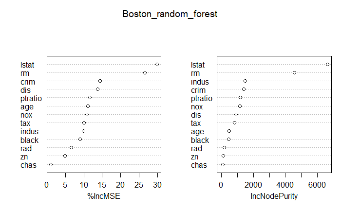

```r
varImpPlot(Boston_random_forest)
```

### Boosting

#### 14) Using the gbm() function like following, fit a boosted model on the training set. Then compare its performance with the previous models by calculating the predictions and the RMSE.

```r
library(gbm)
Boston_boost = gbm(medv ~ ., data = Boston_train, distribution = "gaussian",
                    n.trees = 5000, interaction.depth = 4, shrinkage = 0.01)
Boston_boost_predictions = predict(Boston_boost, newdata = Boston_test)
```

```
Using 5000 trees...
```

```r
RMSE(Boston_boost_predictions, Boston_test$medv)
```

```
[1] 3.639268
```

#### 15) Show the summary of the boosted model. A figure of the variable importance will be shown.

|  | var | rel.inf |
| --- | --- | --- |
| lstat | lstat | 45.89376800 |
| rm | rm | 25.15454348 |
| dis | dis | 5.82334455 |
| nox | nox | 5.08335032 |
| crim | crim | 4.91347300 |
| black | black | 3.61128041 |
| age | age | 2.86936573 |
| ptratio | ptratio | 2.76007758 |
| tax | tax | 2.10131243 |
| indus | indus | 0.90634096 |

[output cut: 3 more lines]

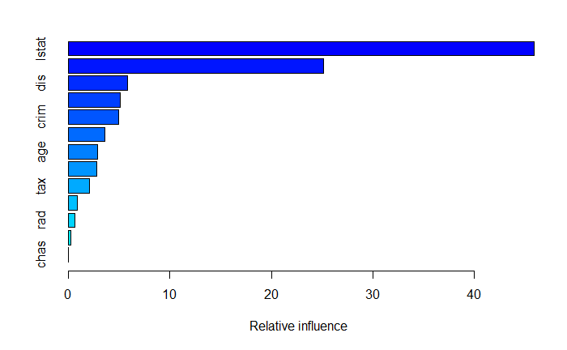

```r
summary(Boston_boost)
```

### Comparison

#### 16) Reproduce the following comparison: A table in which we show the obtained RMSE with each tested model, you can create a 5×2 data.frame in which you put the names of the models and the corresponding RMSE. To visualize the data frame in the compiled html report you can use the kable() function from the knitr package. Or, compare the models by plotting the Actual (reality) response values against the predicted values.

```r
library(knitr)
names <- c("Linear Regression", "Simple tree", "Bagging", "Random Forest", "Boosting")
rmse <- c(RMSE(Boston_lm_predictions, Boston_test$medv), RMSE(Boston_tree_predictions, Boston_test$medv), RMSE(Boston_bagging_predictions, Boston_test$medv), RMSE(Boston_random_forest_predictions, Boston_test$medv), RMSE(Boston_boost_predictions, Boston_test$medv))
df = data.frame(names,rmse)
kable(df)
```

[output not shown]

```r
par(mfrow=c(2,3))
plot(Boston_lm_predictions, Boston_test$medv,
     xlab = "Predicted", ylab = "Actual",
     main = "Linear regression")
abline(0, 1, col = "green")
```

```r
plot(Boston_tree_predictions, Boston_test$medv,
     xlab = "Predicted", ylab = "Actual",
     main = "Single Tree")
abline(0, 1, col = "green")
```

```r
plot(Boston_bagging_predictions, Boston_test$medv,
     xlab = "Predicted", ylab = "Actual",
     main = "Bagging")
abline(0, 1, col = "green")
```

```r
plot(Boston_random_forest_predictions, Boston_test$medv,
     xlab = "Predicted", ylab = "Actual",
     main = "Random Forest")
abline(0, 1, col = "green")
```

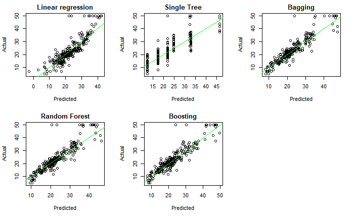

```r
plot(Boston_boost_predictions, Boston_test$medv,
     xlab = "Predicted", ylab = "Actual",
     main = "Boosting")
abline(0, 1, col = "green")
```

## Classification Trees

For the rest of this PW, you must: Import the spam dataset and explore it. Be aware that it is preferable that the response column is of type factor. Split the dataset into training and test sets (choose your own seed when using set.seed()). Fit (using rpart and gbm packages): A logistic regression model. A simple classification tree. Bagging, Random Forests22, and Boosting models. For each model, predict the response on the test set and evaluate the performance of the model, using the prediction accuracy (create a function that returns the accuracy for two binary vectors). ### The Spam dataset

```r
spam = read.csv("spam.csv")
spam$spam = as.factor(spam$spam)
spam
```

[output not shown]

[output cut: 990 more lines]

```r
str(spam)
```

```
'data.frame':   4601 obs. of  58 variables:
 $ spam      : Factor w/ 2 levels "FALSE","TRUE": 2 2 2 2 2 2 2 2 2 2 ...
 $ make      : num  0 0.21 0.06 0 0 0 0 0 0.15 0.06 ...
 $ address   : num  0.64 0.28 0 0 0 0 0 0 0 0.12 ...
 $ all       : num  0.64 0.5 0.71 0 0 0 0 0 0.46 0.77 ...
 $ X3d       : num  0 0 0 0 0 0 0 0 0 0 ...
 $ our       : num  0.32 0.14 1.23 0.63 0.63 1.85 1.92 1.88 0.61 0.19 ...
 $ over      : num  0 0.28 0.19 0 0 0 0 0 0 0.32 ...
 $ remove    : num  0 0.21 0.19 0.31 0.31 0 0 0 0.3 0.38 ...
 $ internet  : num  0 0.07 0.12 0.63 0.63 1.85 0 1.88 0 0 ...
 $ order     : num  0 0 0.64 0.31 0.31 0 0 0 0.92 0.06 ...
 $ mail      : num  0 0.94 0.25 0.63 0.63 0 0.64 0 0.76 0 ...
 $ receive   : num  0 0.21 0.38 0.31 0.31 0 0.96 0 0.76 0 ...
 $ will      : num  0.64 0.79 0.45 0.31 0.31 0 1.28 0 0.92 0.64 ...
 $ people    : num  0 0.65 0.12 0.31 0.31 0 0 0 0 0.25 ...
```

[output cut: 44 more lines]

```r
summary(spam)
```

```
    spam           make           address            all              X3d                our               over            remove          internet           order              mail            receive
 FALSE:2788   Min.   :0.0000   Min.   : 0.000   Min.   :0.0000   Min.   : 0.00000   Min.   : 0.0000   Min.   :0.0000   Min.   :0.0000   Min.   : 0.0000   Min.   :0.00000   Min.   : 0.0000   Min.   :0.00000
 TRUE :1813   1st Qu.:0.0000   1st Qu.: 0.000   1st Qu.:0.0000   1st Qu.: 0.00000   1st Qu.: 0.0000   1st Qu.:0.0000   1st Qu.:0.0000   1st Qu.: 0.0000   1st Qu.:0.00000   1st Qu.: 0.0000   1st Qu.:0.00000
              Median :0.0000   Median : 0.000   Median :0.0000   Median : 0.00000   Median : 0.0000   Median :0.0000   Median :0.0000   Median : 0.0000   Median :0.00000   Median : 0.0000   Median :0.00000
              Mean   :0.1046   Mean   : 0.213   Mean   :0.2807   Mean   : 0.06542   Mean   : 0.3122   Mean   :0.0959   Mean   :0.1142   Mean   : 0.1053   Mean   :0.09007   Mean   : 0.2394   Mean   :0.05982
              3rd Qu.:0.0000   3rd Qu.: 0.000   3rd Qu.:0.4200   3rd Qu.: 0.00000   3rd Qu.: 0.3800   3rd Qu.:0.0000   3rd Qu.:0.0000   3rd Qu.: 0.0000   3rd Qu.:0.00000   3rd Qu.: 0.1600   3rd Qu.:0.00000
              Max.   :4.5400   Max.   :14.280   Max.   :5.1000   Max.   :42.81000   Max.   :10.0000   Max.   :5.8800   Max.   :7.2700   Max.   :11.1100   Max.   :5.26000   Max.   :18.1800   Max.   :2.61000
      will            people            report           addresses           free            business          email             you             credit              your              font              X000
 Min.   :0.0000   Min.   :0.00000   Min.   : 0.00000   Min.   :0.0000   Min.   : 0.0000   Min.   :0.0000   Min.   :0.0000   Min.   : 0.000   Min.   : 0.00000   Min.   : 0.0000   Min.   : 0.0000   Min.   :0.0000
 1st Qu.:0.0000   1st Qu.:0.00000   1st Qu.: 0.00000   1st Qu.:0.0000   1st Qu.: 0.0000   1st Qu.:0.0000   1st Qu.:0.0000   1st Qu.: 0.000   1st Qu.: 0.00000   1st Qu.: 0.0000   1st Qu.: 0.0000   1st Qu.:0.0000
 Median :0.1000   Median :0.00000   Median : 0.00000   Median :0.0000   Median : 0.0000   Median :0.0000   Median :0.0000   Median : 1.310   Median : 0.00000   Median : 0.2200   Median : 0.0000   Median :0.0000
 Mean   :0.5417   Mean   :0.09393   Mean   : 0.05863   Mean   :0.0492   Mean   : 0.2488   Mean   :0.1426   Mean   :0.1847   Mean   : 1.662   Mean   : 0.08558   Mean   : 0.8098   Mean   : 0.1212   Mean   :0.1016
 3rd Qu.:0.8000   3rd Qu.:0.00000   3rd Qu.: 0.00000   3rd Qu.:0.0000   3rd Qu.: 0.1000   3rd Qu.:0.0000   3rd Qu.:0.0000   3rd Qu.: 2.640   3rd Qu.: 0.00000   3rd Qu.: 1.2700   3rd Qu.: 0.0000   3rd Qu.:0.0000
 Max.   :9.6700   Max.   :5.55000   Max.   :10.00000   Max.   :4.4100   Max.   :20.0000   Max.   :7.1400   Max.   :9.0900   Max.   :18.750   Max.   :18.18000   Max.   :11.1100   Max.   :17.1000   Max.   :5.4500
     money                hp               hpl              george             X650             lab                labs            telnet              X857              data               X415
 Min.   : 0.00000   Min.   : 0.0000   Min.   : 0.0000   Min.   : 0.0000   Min.   :0.0000   Min.   : 0.00000   Min.   :0.0000   Min.   : 0.00000   Min.   :0.00000   Min.   : 0.00000   Min.   :0.00000
 1st Qu.: 0.00000   1st Qu.: 0.0000   1st Qu.: 0.0000   1st Qu.: 0.0000   1st Qu.:0.0000   1st Qu.: 0.00000   1st Qu.:0.0000   1st Qu.: 0.00000   1st Qu.:0.00000   1st Qu.: 0.00000   1st Qu.:0.00000
 Median : 0.00000   Median : 0.0000   Median : 0.0000   Median : 0.0000   Median :0.0000   Median : 0.00000   Median :0.0000   Median : 0.00000   Median :0.00000   Median : 0.00000   Median :0.00000
 Mean   : 0.09427   Mean   : 0.5495   Mean   : 0.2654   Mean   : 0.7673   Mean   :0.1248   Mean   : 0.09892   Mean   :0.1029   Mean   : 0.06475   Mean   :0.04705   Mean   : 0.09723   Mean   :0.04784
 3rd Qu.: 0.00000   3rd Qu.: 0.0000   3rd Qu.: 0.0000   3rd Qu.: 0.0000   3rd Qu.:0.0000   3rd Qu.: 0.00000   3rd Qu.:0.0000   3rd Qu.: 0.00000   3rd Qu.:0.00000   3rd Qu.: 0.00000   3rd Qu.:0.00000
 Max.   :12.50000   Max.   :20.8300   Max.   :16.6600   Max.   :33.3300   Max.   :9.0900   Max.   :14.28000   Max.   :5.8800   Max.   :12.50000   Max.   :4.76000   Max.   :18.18000   Max.   :4.76000
      X85            technology          X1999           parts              pm               direct              cs             meeting           original         project              re               edu
 Min.   : 0.0000   Min.   :0.00000   Min.   :0.000   Min.   :0.0000   Min.   : 0.00000   Min.   :0.00000   Min.   :0.00000   Min.   : 0.0000   Min.   :0.0000   Min.   : 0.0000   Min.   : 0.0000   Min.   : 0.0000
```

[output cut: 12 more lines]

```r
compute_acc = function(y, y_hat) {
  mean(y == y_hat)
}
```

```r
library(caTools)
set.seed(0)
split = sample.split(spam$spam, SplitRatio = 0.75)
training_set = subset(spam, split == TRUE)
test_set = subset(spam, split == FALSE)
```

#### Logistic Regression

```r
spam_logistic_regression <- glm(spam ~ ., family = "binomial", data=training_set)
```

[output not shown]

```r
summary(spam_logistic_regression)
```

```
Call:
glm(formula = spam ~ ., family = "binomial", data = training_set)

Deviance Residuals:
    Min       1Q   Median       3Q      Max
-4.3805  -0.1757   0.0000   0.1012   3.7469

Coefficients:
              Estimate Std. Error z value Pr(>|z|)
(Intercept) -1.560e+00  1.707e-01  -9.143  < 2e-16 ***
make        -2.387e-01  2.640e-01  -0.904 0.366015
address     -1.568e-01  8.993e-02  -1.744 0.081233 .
all          6.491e-02  1.484e-01   0.437 0.661862
X3d          2.848e+00  1.825e+00   1.560 0.118692
our          5.679e-01  1.173e-01   4.842 1.29e-06 ***
over         8.410e-01  2.975e-01   2.827 0.004700 **
remove       2.567e+00  4.124e-01   6.225 4.81e-10 ***
internet     5.488e-01  1.763e-01   3.113 0.001853 **
order        1.304e+00  4.106e-01   3.176 0.001493 **
mail         8.845e-02  8.213e-02   1.077 0.281546
receive     -7.196e-01  3.898e-01  -1.846 0.064850 .
will        -1.439e-01  8.859e-02  -1.625 0.104251
people      -5.136e-02  2.930e-01  -0.175 0.860855
report       2.606e-02  1.586e-01   0.164 0.869526
addresses    1.008e+00  7.233e-01   1.393 0.163560
free         1.134e+00  1.742e-01   6.511 7.45e-11 ***
business     9.580e-01  2.644e-01   3.623 0.000291 ***
email       -6.243e-02  1.381e-01  -0.452 0.651318
you          6.545e-02  4.372e-02   1.497 0.134389
credit       1.065e+00  5.962e-01   1.786 0.074043 .
your         2.446e-01  6.448e-02   3.793 0.000149 ***
font         1.241e-01  1.562e-01   0.795 0.426814
X000         2.329e+00  5.985e-01   3.891 9.98e-05 ***
money        3.864e-01  1.992e-01   1.940 0.052438 .
hp          -2.170e+00  3.896e-01  -5.570 2.54e-08 ***
hpl         -1.019e+00  4.997e-01  -2.039 0.041437 *
george      -2.016e+01  3.546e+00  -5.686 1.30e-08 ***
X650         5.410e-01  2.347e-01   2.305 0.021178 *
lab         -2.121e+00  1.553e+00  -1.366 0.171990
labs         9.285e-02  3.321e-01   0.280 0.779789
```

[output cut: 22 more lines]

```
ch..4        6.256e+00  8.829e-01   7.085 1.39e-12 ***
ch..5        1.924e+00  1.334e+00   1.443 0.149160
crl.ave      2.940e-02  2.773e-02   1.060 0.289147
crl.long     1.289e-02  3.139e-03   4.107 4.01e-05 ***
crl.tot      6.031e-04  2.431e-04   2.481 0.013118 *
---
Signif. codes:  0 ‘***’ 0.001 ‘**’ 0.01 ‘*’ 0.05 ‘.’ 0.1 ‘ ’ 1

(Dispersion parameter for binomial family taken to be 1)

    Null deviance: 4628.1  on 3450  degrees of freedom
Residual deviance: 1274.4  on 3393  degrees of freedom
AIC: 1390.4

Number of Fisher Scoring iterations: 14
```

```r
spam_logistic_regression_pred = predict(spam_logistic_regression, newdata = test_set, type="response")
spam_logistic_regression_bin_pred = ifelse(spam_logistic_regression_pred >= 0.5, TRUE,FALSE)
spam_logistic_regression_acc = compute_acc(spam_logistic_regression_bin_pred, test_set$spam)
spam_logistic_regression_acc
```

```
[1] 0.9217391
```

#### Tree

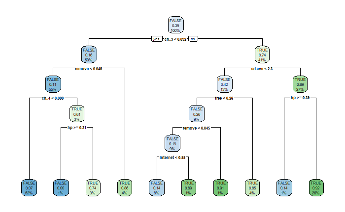

```r
spam_tree = rpart(spam ~ ., data = training_set)
rpart.plot(spam_tree)
```

```r
spam_tree_pred = predict(spam_tree, newdata = test_set, type="class")
spam_tree_acc = compute_acc(spam_tree_pred, test_set$spam)
spam_tree_acc
```

```
[1] 0.8973913
```

#### Bagging

```r
spam_bagging = randomForest(spam ~ ., data = training_set, mtry = ncol(spam)-1,
                        importance = TRUE, ntrees = 500)
spam_bagging
```

```
Call:
 randomForest(formula = spam ~ ., data = training_set, mtry = ncol(spam) -      1, importance = TRUE, ntrees = 500)
               Type of random forest: classification
                     Number of trees: 500
No. of variables tried at each split: 57

        OOB estimate of  error rate: 5.97%
Confusion matrix:
      FALSE TRUE class.error
FALSE  1997   94  0.04495457
TRUE    112 1248  0.08235294
```

```r
spam_bagging_pred = predict(spam_bagging, newdata = test_set, type="class")
spam_bagging_acc = compute_acc(spam_bagging_pred, test_set$spam)
spam_bagging_acc
```

```
[1] 0.9478261
```

#### Random_forest

```r
spam_random_forest = randomForest(spam ~ ., data = training_set, mtry = as.integer(sqrt(ncol(spam)-1)),
                        importance = TRUE, ntrees = 500)
spam_random_forest
```

```
Call:
 randomForest(formula = spam ~ ., data = training_set, mtry = as.integer(sqrt(ncol(spam) -      1)), importance = TRUE, ntrees = 500)
               Type of random forest: classification
                     Number of trees: 500
No. of variables tried at each split: 7

        OOB estimate of  error rate: 4.93%
Confusion matrix:
      FALSE TRUE class.error
FALSE  2024   67  0.03204209
TRUE    103 1257  0.07573529
```

```r
spam_random_forest_pred = predict(spam_random_forest, newdata = test_set, type="class")
spam_random_forest_acc = compute_acc(spam_random_forest_pred, test_set$spam)
spam_random_forest_acc
```

```
[1] 0.9556522
```

#### Boosting

```r
training_set$spam01 = ifelse(training_set$spam == FALSE, 0, 1)
test_set$spam01 = ifelse(test_set$spam == FALSE, 0, 1)
# We use a bernoulli distribution because the response is between 0 ou 1
spam_boosting = gbm(spam01 ~ . - spam, data = training_set, distribution = "bernoulli",
                 n.trees = 5000)
spam_boosting
```

```
gbm(formula = spam01 ~ . - spam, distribution = "bernoulli",
    data = training_set, n.trees = 5000)
A gradient boosted model with bernoulli loss function.
5000 iterations were performed.
There were 57 predictors of which 50 had non-zero influence.
```

```r
spam_boosting_pred = predict(spam_boosting, test_set, type = "response")
```

```
Using 5000 trees...
```

```r
spam_boost_bin_pred = ifelse(spam_boosting_pred >= 0.5, 1,0)
spam_boosting_acc = compute_acc(spam_boost_bin_pred, test_set$spam01)
spam_boosting_acc
```

```
[1] 0.9443478
```

#### Comparison

```r
accuracies_table = data.frame(
  Model = c("Logistic Regression", "Single Tree", "Bagging",  "Random Forest",  "Boosting"),
  TestAccuracy = c(spam_logistic_regression_acc, spam_tree_acc, spam_bagging_acc, spam_random_forest_acc, spam_boosting_acc)
  )

kable(accuracies_table)
```

| Model | TestAccuracy |
| --- | --- |
| Logistic Regression | 0.9217391 |
| Single Tree | 0.8973913 |
| Bagging | 0.9478261 |
| Random Forest | 0.9556522 |
| Boosting | 0.9443478 |